# Lecture 13: Age models part 2

1. Building an age model
   - dealing with uncertainty
2. Introduction to carbonates

*We acknowledge and respect the lək̓ʷəŋən peoples on whose traditional territory the university stands and the Songhees, Esquimalt and W̱SÁNEĆ peoples whose historical relationships with the land continue to this day.*

```python
from matplotlib.patches import Polygon
import scipy.stats as stats
from scipy.interpolate import interp1d
from matplotlib import pyplot as plt
import numpy as np
```

```python
def rando_strat(ax,num_box,height,boxes,liths):
    box_colors= [('#FFB142',0.6),('#33D9B2',0.5),('#34ACE0',0.4),('#706FD3',0.3),('#2C2C54',0.2),('#84817A',0.1)]
    if len(boxes)==0:
        boxes=np.cumsum(np.random.gamma(1,1, num_box))
        boxes=boxes/boxes[-1]*height
        boxes=np.hstack((boxes[0],np.diff(boxes)))
        liths=np.random.randint(0,len(box_colors),num_box)
    stack=0
    trace=[]
    for i,s in enumerate(boxes):
        tmp_w=box_colors[liths[i]][1]
        tmp_color=box_colors[liths[i]][0]
        #add a lithostratigraphy box
        xy=np.array([(0,stack),
                     (0+tmp_w,stack),
                     (0+tmp_w,stack+s),
                     (0,stack+s)])
        rect = Polygon(xy,closed=True,
                      facecolor=tmp_color,edgecolor="k",lw=0.5)
        ax.add_patch(rect)
        #grow the net record
        trace.append((stack,stack+s,tmp_w))
        stack=stack+s
    #set y-limits (from height of this column)
    ax.set_ylim([-0.1,height+0.01*height])
    #set x-limits (section-specific max width of strat box)
    ax.set_xlim([0,1])
    #turn off axes and frame
    ax.axis('off')
    return ax,np.array(trace),boxes,liths
```

```python
def calc_age(ash_table,h):
    up=ash_table[(ash_table[:,1])>h][0]
    down=ash_table[(ash_table[:,1])<h][-1]
    sed_rate=(up[1]-down[1])/(down[0]-up[0]) #[1] is height, [0] is age

    h_diff=h-down[1]
    h_age=down[0]-h_diff/sed_rate

    return(h_age)

ashes={'ash1':{'height':0.1,
            'age': 66.153,
            '2sd':0.029},
       'ash2':{'height':0.83,
            'age': 66.043,
            '2sd':0.031},
       'ash3':{'height':1.6,
            'age': 65.985,
            '2sd':0.011}}
ash_table=np.array([(ashes[a]['age'],ashes[a]['height']) for a in ashes])
KT=0.6 #height in meters
```

```python
def plot_ash(boxes = [], liths = []):
    fig=plt.figure(1,figsize=(15,6))
    ax=fig.add_subplot(121)
    ax,trace,boxes,liths=rando_strat(ax,num_box=5,height=2,boxes=boxes,liths=liths) #stratigraphy for fun
    #ashes in the strat column
    for a in ashes:
        tmp_w=trace[(trace[:,0]<=ashes[a]['height']) & (trace[:,1]>ashes[a]['height']),2]
        ax.plot([0,tmp_w],[ashes[a]['height'],ashes[a]['height']],'r--')
    #KT boundary
    tmp_w=trace[(trace[:,0]<=KT) & (trace[:,1]>KT),2]
    ax.plot([0,tmp_w],[KT,KT],'k--')
    ax.text(tmp_w,KT,'  KT boundary',verticalalignment='center',fontsize=20)
    #ash ages
    ax=fig.add_subplot(122)
    for a in ashes:
        ax.plot(ashes[a]['age'],ashes[a]['height'],'rs')
    ax.plot([66.2,65.95],[KT,KT],'k--')
    ax.set_xlim([66.2,65.95]); ax.set_ylim([-0.1,2])
    ax.set_ylabel('meters'); _=ax.set_xlabel('age (Ma)')
    return boxes, liths, fig
```

##### Building an age model

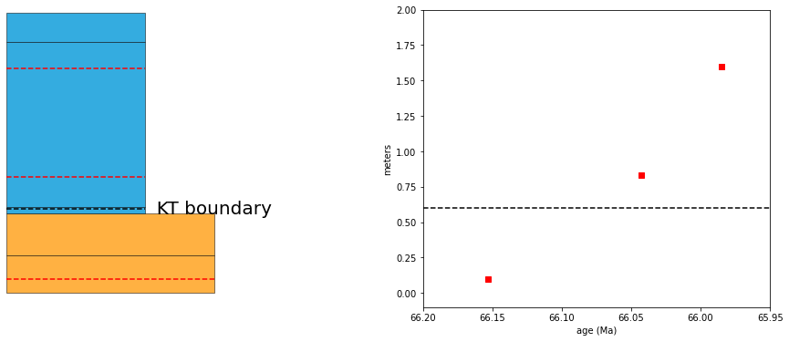

```python
boxes, liths, _ = plot_ash()
```

What is the age of the *KT Boundary*? What ages are possible? What ages are most likely?

##### Building an age model

Starting simple since we cant assume slow then fast is any more likely than fast then slow. Considering a constant sedimentation rate (a linear interpolation)..

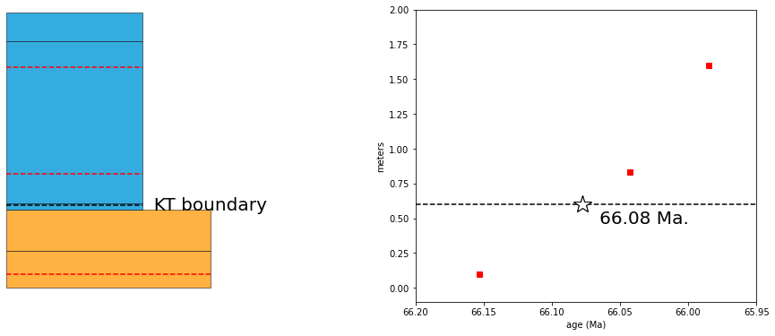

```python
_,_, fig = plot_ash(boxes=boxes,liths=liths)
#calculate KT age
ax = fig.axes[-1]
KT_age=calc_age(ash_table,KT)
ax.plot([KT_age,KT_age],[KT,KT],'w*',mec='k',markersize=20)
_=ax.text(KT_age,KT-.1,'   %2.2f Ma.' % (KT_age),horizontalalignment='left',verticalalignment='center',fontsize=20)
```

Even with the simple model.. what havn't we considered?

##### Building an age model

Starting simple since we cant assume slow then fast is any more likely than fast then slow. Considering a constant sedimentation rate (a linear interpolation)..

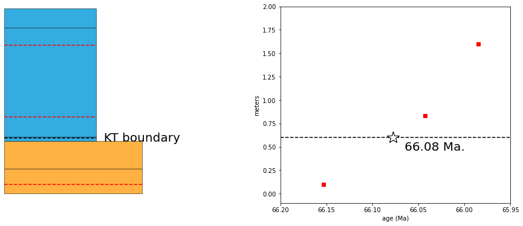

```python
_,_, fig = plot_ash(boxes=boxes,liths=liths)
#calculate KT age
ax = fig.axes[-1]
KT_age=calc_age(ash_table,KT)
ax.plot([KT_age,KT_age],[KT,KT],'w*',mec='k',markersize=20)
_=ax.text(KT_age,KT-.1,'   %2.2f Ma.' % (KT_age),horizontalalignment='left',verticalalignment='center',fontsize=20)
```

Even with the simple model.. what havn't we considered? Uncertainty in the geochronology

##### Building an age model

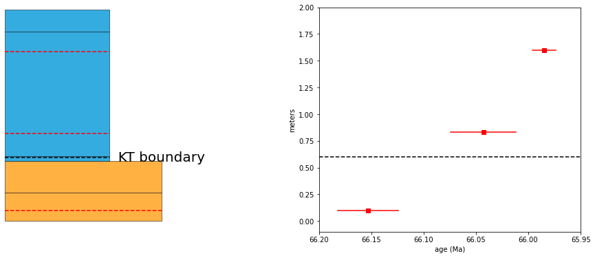

```python
_,_, fig = plot_ash(boxes=boxes,liths=liths)
ax = fig.axes[-1]
for a in ashes:
    ax.plot(ashes[a]['age'],ashes[a]['height'],'rs')
    ax.plot([ashes[a]['age']+ashes[a]['2sd'],ashes[a]['age']-ashes[a]['2sd']],
            [ashes[a]['height'],ashes[a]['height']],'r-')
```

##### Building an age model

How can we describe the uncertainty of the ash ages?

##### Building an age model

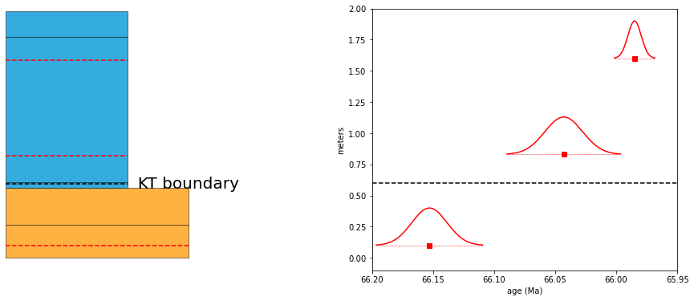

```python
_,_, fig = plot_ash(boxes=boxes,liths=liths)
ax = fig.axes[-1]
for a in ashes:
    mu=ashes[a]['age'] #normal distribution
    sigma=ashes[a]['2sd']/2
    x = np.linspace(mu - 3*sigma, mu + 3*sigma, 300)
    distro=stats.norm.pdf(x, mu, sigma) #scaled for display
    distro=distro/max(distro)*0.3
    ax.plot(x, distro+ashes[a]['height'],'r')
    #ash strat height
    ax.plot([ashes[a]['age']+ashes[a]['2sd']*3/2,ashes[a]['age']-ashes[a]['2sd']*3/2],
            [ashes[a]['height'],ashes[a]['height']],'r--',lw=0.5)
```

##### Building an age model

How do we include these *normally distributed* uncertainties into our constant sedimentation rate age model?

Consider..

$$ Z = (Y\pm\sigma_Y) + (X\pm\sigma_X) $$

What is Z? What is $\sigma_Z$?

##### Building an age model

How do we include these *normally distributed* uncertainties into our constant sedimentation rate age model?

Consider..

$$ Z = (Y\pm\sigma_Y) + (X\pm\sigma_X) $$

What is Z? (sum of the means) What is $\sigma_Z$? (square root of $\Sigma\sigma^2$)

```python
import numpy as np
Y = np.random.normal(2,.3,1000000)
X = np.random.normal(20,.2,1000000)
Z = Y + X
print(f"""Mean of Z: {np.mean(Z):.1f} and standard deviation of Z: {np.std(Z):.2f}
Analytical stdev: {(.3**2+.2**2)**(1/2):.2f}""")
```

```
Mean of Z: 22.0 and standard deviation of Z: 0.36
Analytical stdev: 0.36
```

##### Building an age model

How do we include these *normally distributed* uncertainties into our constant sedimentation rate age model?

Consider..

$$ Z = (Y\pm\sigma_Y) \times (X\pm\sigma_X) $$

What is Z? What is $\sigma_Z$?

##### Building an age model

How do we include these *normally distributed* uncertainties into our constant sedimentation rate age model?

Consider..

$$ Z = (Y\pm\sigma_Y) \times (X\pm\sigma_X) $$

What is Z? (product of the means) What is $\sigma_Z$? (square root of the sum of the relative errors squared times mean of Z)

$$ \frac{\sigma_Z}{Z} \approx \left(\left(\frac{\sigma_Y}{Y}\right)^2 + \left(\frac{\sigma_X}{X}\right)^2\right)^\frac{1}{2} $$

```python
import numpy as np
Y = np.random.normal(2,.3,1000000)
X = np.random.normal(20,.2,1000000)
Z = Y * X
print(f"""Mean of Z: {np.mean(Z):.1f} and standard deviation of Z: {np.std(Z):.1f}
Analytical stdev: {np.mean(Z)*((0.3/2)**2+(0.2/20)**2)**(1/2):.2f}""")
```

```
Mean of Z: 40.0 and standard deviation of Z: 6.0
Analytical stdev: 6.01
```

##### Building an age model

Let's apply these rules to linear interpolation:

$$\mathrm{ \dfrac{A_{KT}-A_{0}}{H_{KT}-H_{0}}=\dfrac{A_{1}-A_{0}}{H_{1}-H_{0}}\\}$$

##### Building an age model

Let's apply these rules to linear interpolation:

$$\mathrm{ \dfrac{A_{KT}-A_{0}}{H_{KT}-H_{0}}=\dfrac{A_{1}-A_{0}}{H_{1}-H_{0}}\\ A_{KT}=\left(\dfrac{A_{1}-A_{0}}{H_{1}-H_{0}}\right)(H_{KT}-H_{0})+A_{0}\\ }$$

##### Building an age model

Let's apply these rules to linear interpolation:

$$\mathrm{ \dfrac{A_{KT}-A_{0}}{H_{KT}-H_{0}}=\dfrac{A_{1}-A_{0}}{H_{1}-H_{0}}\\ A_{KT}=\left(\dfrac{A_{1}-A_{0}}{H_{1}-H_{0}}\right)(H_{KT}-H_{0})+A_{0}\\ A_{KT}=\left(\dfrac{\color{red}{A_{1}-A_{0}}}{H_{1}-H_{0}}\right)(H_{KT}-H_{0})+\color{red}{A_{0}}\\ } $$

##### Building an age model

Let's apply these rules to linear interpolation:

$$\mathrm{ \dfrac{A_{KT}-A_{0}}{H_{KT}-H_{0}}=\dfrac{A_{1}-A_{0}}{H_{1}-H_{0}}\\ A_{KT}=\left(\dfrac{A_{1}-A_{0}}{H_{1}-H_{0}}\right)(H_{KT}-H_{0})+A_{0}\\ A_{KT}=\left(\dfrac{\color{red}{A_{1}-A_{0}}}{H_{1}-H_{0}}\right)(H_{KT}-H_{0})+\color{red}{A_{0}}\\ \\ \sigma A_{kt}^2=\left((\sigma A_{0}^2 + \sigma A_{1}^2)^\frac{1}{2}\times\frac{H_{KT}-H_{0}}{H_{1}-H_{0}}\right)^2 + \sigma A_{0}^2}$$

```python
age = (
    lambda ashes, ktH: (ashes["ash2"]["age"] - ashes["ash1"]["age"])
    / (ashes["ash2"]["height"] - ashes["ash1"]["height"])
    * (ktH - ashes["ash1"]["height"])
    + ashes["ash1"]["age"]
)
```

```python
draws = []
for i in range(10000):
    simulated_ash = {
        "ash1": {
            "height": 0.1,
            "age": np.random.normal(66.153, 0.029 / 2),
            "2sd": 0.029,
        },
        "ash2": {
            "height": 0.83,
            "age": np.random.normal(66.043, 0.031 / 2),
            "2sd": 0.031,
        },
        "ash3": {
            "height": np.random.normal(66.153, 0.011 / 2),
            "age": 65.985,
            "2sd": 0.011,
        },
    }
    draws.append(age(simulated_ash, KT))
print(np.std(draws))
```

```
0.011619603147695575
```

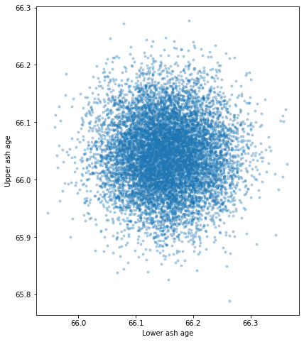

```python
plt.figure(figsize=(8,8))
a1 = np.random.normal(66.153, 0.029 * 2, 10000)
a2 = np.random.normal(66.043, 0.031 * 2, 10000)
plt.plot(a1,a2,'.',alpha=.3)
plt.gca().set_aspect('equal')
plt.gca().set_xlabel('Lower ash age')
plt.gca().set_ylabel('Upper ash age')
```

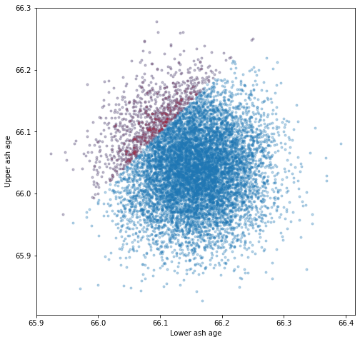

```python
plt.figure(figsize=(8, 8))
a1 = np.random.normal(66.153, 0.029 * 2, 10000)
a2 = np.random.normal(66.043, 0.031 * 2, 10000)
plt.plot(a1, a2, ".", alpha=0.3)
plt.plot(a1[a1 < a2], a2[a1 < a2], "r.", alpha=0.1)
plt.gca().set_aspect("equal")
plt.gca().set_xlabel("Lower ash age")
plt.gca().set_ylabel("Upper ash age")
```

##### Building an age model

How do we include these *normally distributed* uncertainties into our constant sedimentation rate age model?

- Even in our simple model the uncertainty is not exactly normal (there is covariation)
- Random number generators allow us account to account for these more complicated forms of uncertainty (Monte Carlo methods)

# Power of Monte Carlo approaches

[figure not shown]

# How many samples is enough?

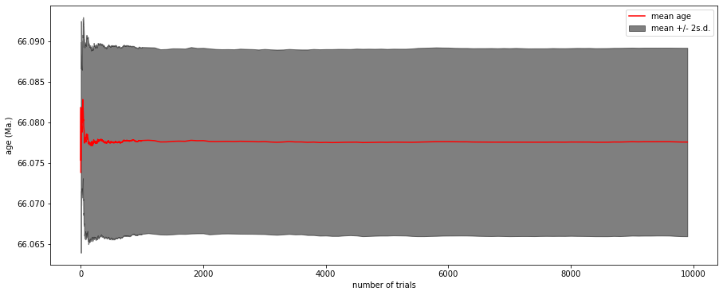

```python
fig=plt.figure(1,figsize=(15,6))
ax=fig.add_subplot(111)
idx=list(range(1000)) +list(range(1000,len(KT_ages)+1,100))
#statistics of KT age as function of number of trials
KT_evolve=[]
for i in idx[:10000]: #more trials here
    KT_evolve.append((np.mean(KT_ages[0:i+1]),np.std(KT_ages[0:i+1]),len(KT_ages[0:i+1])))
KT_evolve=np.array(KT_evolve)
#plot the results
ax.plot(KT_evolve[:,2],KT_evolve[:,0],'r-',label='mean age')
ax.fill_between(KT_evolve[:,2],KT_evolve[:,0]+KT_evolve[:,1],KT_evolve[:,0]-KT_evolve[:,1],
                color='k',alpha=0.5,zorder=0,label='mean +/- 2s.d.')
ax.set_ylabel('age (Ma.)'); ax.set_xlabel('number of trials');_=ax.legend(loc='best')
```

# Constant sedimentation rate assumption

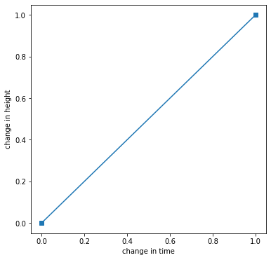

```python
def make_path(pts,g_shape,g_scale,delta):
    #separate a number of points (X) along a [0,1] path
    if pts!=0:
        #X numbers are drawn from a gamma distribution (G)
        #--> these represent the distances between successive points
        path=np.cumsum(np.random.gamma(g_shape,g_scale, pts))
    else:
        path=[1]#if X = 0, then path is simply [0,1]
    path=np.hstack((0,path))#add 0 as the path beginning
    #scale first to be between 0 and 1, and then 0 to delta
    path=path/path[-1]*delta
    return(path)

fig=plt.figure(1,figsize=(6,6)); ax=fig.add_subplot(111)
#assumes constant sedimentation rate between anchors
ax.plot([0,1],[0,1],'-s');ax.set_xlabel('change in time'); _=ax.set_ylabel('change in height')
```

# Constant sedimentation rate assumption

- goal in lab tomorrow: how can we get away from the assumption of constant sedimentation rate? what *should* it look like?

# Carbonates

[figure not shown]